# 4_figures and tables

# Figure 12 mean july temps by species and decade

Summarize data for figure.

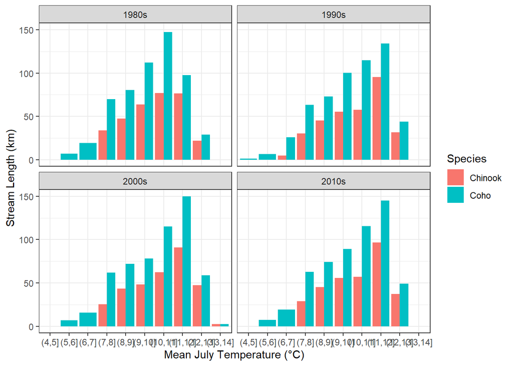

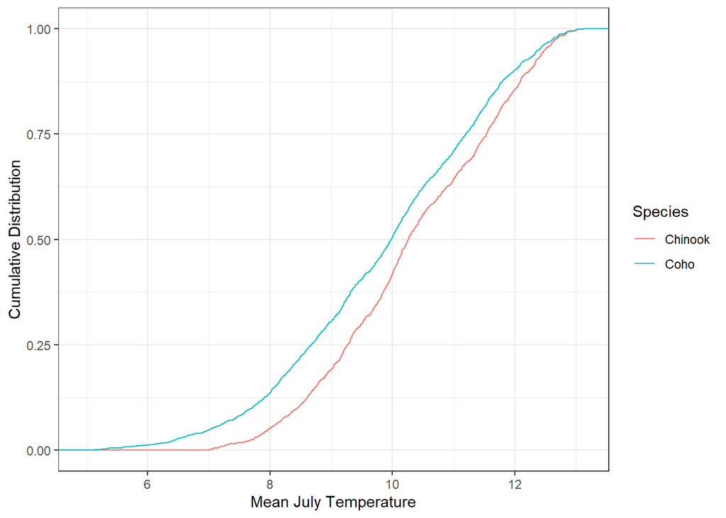

Figure 13. Distribution of maximum 7-day moving average of mean daily temperatures across the Anchor-Stariski watersheds for salmon rearing and spawning habitats. 2004 and 2008 are warm and cold years, respectively, in the dataset of historical predictions (1980-2018).

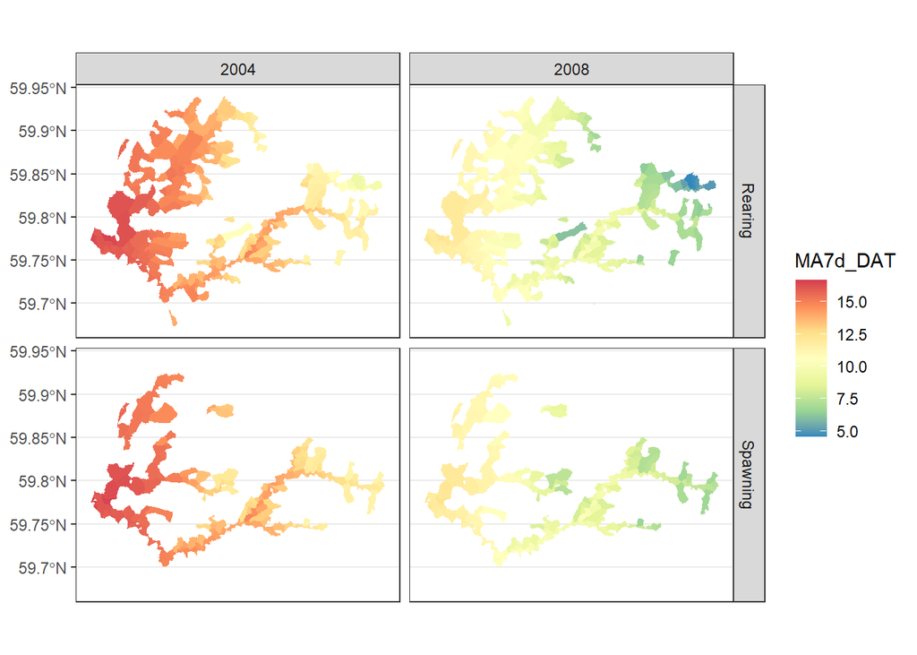

Trying proportions.

Look at distribution of all catchments in Deshka over time.

What about a times series indicating how air temperatures have changed (using daymet)?

Below 0 predictions